# Celebrity_Classification-checkpoint

## Celebrity Image Classification

*This notebook is largely based on [this tutorial](https://github.com/fastai/course-v3/blob/master/nbs/dl1/lesson2-download.ipynb) from [fast.ai](https://www.fast.ai/)*

What it aims to do is classify a person as a celebrity or non-celebrity based on a picture of someone's face. How I tried to do this is by scraping images from Google of celebrities & non-celebrities and running a CNN on these using fastai.vision.

The results indicate that it is not very effective at classifying a celebrity as a celebrity, although it is stronger at classifying non-celebrities as non-celebrities. It has a roughly 20% error-rate as opposed to a 50% error on binary classification. That small bit of classification strength seems to me to be most likely due to differences in the types of photos and the look of the people. Celebrities have a lot more make-up, wear nicer clothes and have more professional photos.

```python
from fastai.vision import *
```

**Get images from google**

1. Search Google Images & load all the images you want
2. Enter the following code after pressing `cmd-Opt-j`

   > `urls=Array.from(document.querySelectorAll('.rg_i')).map(el=> el.hasAttribute('data-src')?el.getAttribute('data-src'):el.getAttribute('data-iurl'));`  
   > `window.open('data:text/csv;charset=utf-8,' + escape(urls.join('\n')));`

**Create directories for images**

```python
folder = 'celebrity'
file = 'celebrity.csv'
```

```python
path = Path('data/celeb')
dest = path/folder
dest.mkdir(parents=True, exist_ok=True)
```

```python
folder = 'non-celebrity'
file = 'non-celebrity.csv'
```

```python
path = Path('data/celeb')
dest = path/folder
dest.mkdir(parents=True, exist_ok=True)
```

```python
path.ls()
```

```
[PosixPath('data/celeb/celebrity'), PosixPath('data/celeb/non-celebrity')]
```

```python
classes = ['celebrity','non-celebrity']
```

*Next, place the* **csv files** *into the* **directory**

**Downloading the Images**

*Note: If it doesn't work the first time, add max_workers = 0 to debug*

```python
path = Path('data/celeb')
folder = 'celebrity'
file = 'celebrity.csv'
dest = path/folder
download_images(path/file, dest, max_pics=200,max_workers=0)

path = Path('data/celeb')
folder = 'non-celebrity'
file = 'non-celebrity.csv'
dest = path/folder
download_images(path/file, dest, max_pics=200)
```

**Cleaning up the images**

```python
for c in classes:
    print(c)
    verify_images(path/c, delete=True, max_size=500)
```

```
celebrity
```

```
non-celebrity
```

**Loading the images as data**

```python
np.random.seed(42)
data = ImageDataBunch.from_folder(path, train=".", valid_pct=0.2,
        ds_tfms=get_transforms(), size=224, num_workers=2).normalize(imagenet_stats)
```

```python
data.classes
```

```
['celebrity', 'non-celebrity']
```

[figure not shown]

```python
data.show_batch(rows=3, figsize=(7,8))
```

```python
data.classes, data.c, len(data.train_ds), len(data.valid_ds)
```

```
(['celebrity', 'non-celebrity'], 2, 320, 80)
```

**Train Model**

```python
model = cnn_learner(data, models.resnet34, metrics=error_rate)
```

```python
model.fit_one_cycle(4)
```

| epoch | train_loss | valid_loss | error_rate | time |
| --- | --- | --- | --- | --- |
| 0 | 1.334501 | 0.899149 | 0.375000 | 00:05 |
| 1 | 1.037931 | 1.612657 | 0.400000 | 00:03 |
| 2 | 0.887936 | 1.323436 | 0.312500 | 00:03 |
| 3 | 0.773652 | 1.115632 | 0.312500 | 00:03 |

```python
model.save('model-1')
```

*The model appears to have a learning rate that is too low as the validation loss is greater than the training loss at points, indicating that we aren't fitting the data enough*

```python
model.lr_find()
```

85.00% [17/20 00:49<00:08]

| epoch | train_loss | valid_loss | error_rate | time |
| --- | --- | --- | --- | --- |
| 0 | 0.641740 | #na# | 00:03 |  |
| 1 | 0.596982 | #na# | 00:02 |  |
| 2 | 0.580826 | #na# | 00:02 |  |
| 3 | 0.553811 | #na# | 00:02 |  |
| 4 | 0.552708 | #na# | 00:02 |  |
| 5 | 0.553494 | #na# | 00:02 |  |
| 6 | 0.547707 | #na# | 00:02 |  |
| 7 | 0.527690 | #na# | 00:02 |  |
| 8 | 0.514059 | #na# | 00:03 |  |
| 9 | 0.507974 | #na# | 00:02 |  |
| 10 | 0.505585 | #na# | 00:02 |  |
| 11 | 0.512098 | #na# | 00:02 |  |
| 12 | 0.477990 | #na# | 00:02 |  |
| 13 | 0.472666 | #na# | 00:02 |  |
| 14 | 0.518392 | #na# | 00:02 |  |
| 15 | 0.657513 | #na# | 00:02 |  |
| 16 | 1.265712 | #na# | 00:02 |  |

60.00% [3/5 00:02<00:01 1.7796]

```
LR Finder is complete, type {learner_name}.recorder.plot() to see the graph.
```

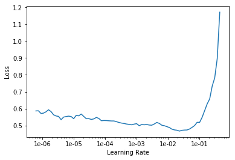

```python
model.recorder.plot()
```

```python
model.fit_one_cycle(5, max_lr=slice(1e-03,1e-02))
```

| epoch | train_loss | valid_loss | error_rate | time |
| --- | --- | --- | --- | --- |
| 0 | 0.187428 | 0.942903 | 0.275000 | 00:03 |
| 1 | 0.180430 | 1.021243 | 0.275000 | 00:03 |
| 2 | 0.183377 | 1.025496 | 0.262500 | 00:03 |
| 3 | 0.166393 | 1.151478 | 0.237500 | 00:03 |
| 4 | 0.161332 | 1.115199 | 0.237500 | 00:03 |

```python
model.save('model-2')
```

```python
model.unfreeze()
```

```python
model.lr_find()
```

55.00% [11/20 00:42<00:34]

| epoch | train_loss | valid_loss | error_rate | time |
| --- | --- | --- | --- | --- |
| 0 | 0.201418 | #na# | 00:04 |  |
| 1 | 0.193598 | #na# | 00:03 |  |
| 2 | 0.187144 | #na# | 00:03 |  |
| 3 | 0.198188 | #na# | 00:03 |  |
| 4 | 0.202759 | #na# | 00:03 |  |
| 5 | 0.181485 | #na# | 00:03 |  |
| 6 | 0.168416 | #na# | 00:03 |  |
| 7 | 0.162273 | #na# | 00:03 |  |
| 8 | 0.160059 | #na# | 00:03 |  |
| 9 | 0.182649 | #na# | 00:03 |  |
| 10 | 0.275469 | #na# | 00:03 |  |

20.00% [1/5 00:01<00:05 0.2995]

```
LR Finder is complete, type {learner_name}.recorder.plot() to see the graph.
```

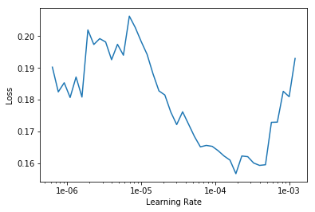

```python
model.recorder.plot()
```

```python
model.fit_one_cycle(3, max_lr=slice(3e-5,3e-4))
```

| epoch | train_loss | valid_loss | error_rate | time |
| --- | --- | --- | --- | --- |
| 0 | 0.197009 | 0.989293 | 0.237500 | 00:04 |
| 1 | 0.191483 | 1.249709 | 0.312500 | 00:04 |
| 2 | 0.185999 | 1.280655 | 0.312500 | 00:04 |

```python
model.save('model-3')
```

Our model with the lowest error_rate appears to be model 2.  
**Let's load this model and see what the results indicate.**

```python
model.load('model-2');
```

```python
interp = ClassificationInterpretation.from_learner(model)
```

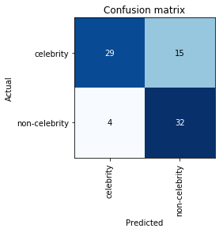

```python
interp.plot_confusion_matrix()
```

*It appears that our model predicts people celebrities as non-celebrities more often than the predicting non-celebrities as celebrities.* *Let's visualize some of these errors*

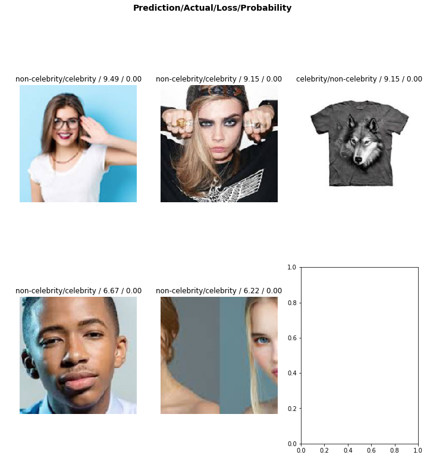

```python
interp.plot_top_losses(k=5)
```

*As we can see, some of these make sense as they are really noisy photos... let's clean up the photos and then, see how our model performs*

### Cleaning Up

```python
from fastai.widgets import *
```

```python
#not quite sure what this is doing
db = (ImageList.from_folder(path)
                   .split_none()
                   .label_from_folder()
                   .transform(get_transforms(), size=224)
                   .databunch()
     )
```

```python
learn_cln = cnn_learner(db, models.resnet34, metrics=error_rate)
learn_cln.load('model-2');
```

```python
#not sure what this does
ds, idxs = DatasetFormatter().from_toplosses(learn_cln)
```

```python
ImageCleaner(ds, idxs, path)
```

*Now that we have cleaned our dataset, we must recreate our model from the cleaned.csv file*

```python
path = Path('data/celeb')
np.random.seed(42)
cleaned_data = ImageDataBunch.from_csv(path, size=224, valid_pct=0.2,
    ds_tfms=get_transforms(), csv_labels='cleaned.csv').normalize(imagenet_stats)
```

```python
cleaned_data.classes
```

```
['celebrity', 'non-celebrity']
```

```python
cleaned_data.classes, cleaned_data.c, len(cleaned_data.train_ds), len(cleaned_data.valid_ds)
```

```
(['celebrity', 'non-celebrity'], 2, 302, 75)
```

```python
clean_model = cnn_learner(cleaned_data, models.resnet34, metrics=error_rate)
```

```python
clean_model.fit_one_cycle(4)
```

| epoch | train_loss | valid_loss | error_rate | time |
| --- | --- | --- | --- | --- |
| 0 | 1.326101 | 1.053406 | 0.400000 | 00:04 |
| 1 | 1.036852 | 1.376687 | 0.426667 | 00:03 |
| 2 | 0.902953 | 1.056261 | 0.333333 | 00:03 |
| 3 | 0.786059 | 0.875284 | 0.293333 | 00:03 |

```python
clean_model.save('model-1')
```

```python
clean_model.load('model-1');
```

```python
clean_model.unfreeze()
```

```python
clean_model.lr_find(start_lr=1e-5, end_lr=1e-1)
```

96.00% [24/25 01:24<00:03]

| epoch | train_loss | valid_loss | error_rate | time |
| --- | --- | --- | --- | --- |
| 0 | 0.410928 | #na# | 00:03 |  |
| 1 | 0.409005 | #na# | 00:03 |  |
| 2 | 0.414558 | #na# | 00:03 |  |
| 3 | 0.404135 | #na# | 00:03 |  |
| 4 | 0.369585 | #na# | 00:03 |  |
| 5 | 0.348143 | #na# | 00:03 |  |
| 6 | 0.325680 | #na# | 00:03 |  |
| 7 | 0.297367 | #na# | 00:03 |  |
| 8 | 0.266755 | #na# | 00:03 |  |
| 9 | 0.250001 | #na# | 00:03 |  |
| 10 | 0.234860 | #na# | 00:03 |  |
| 11 | 0.243259 | #na# | 00:03 |  |
| 12 | 0.245888 | #na# | 00:03 |  |
| 13 | 0.296493 | #na# | 00:03 |  |
| 14 | 0.355323 | #na# | 00:03 |  |
| 15 | 0.433954 | #na# | 00:03 |  |
| 16 | 0.470684 | #na# | 00:03 |  |
| 17 | 0.511061 | #na# | 00:03 |  |
| 18 | 0.542839 | #na# | 00:03 |  |
| 19 | 0.586056 | #na# | 00:03 |  |
| 20 | 0.619719 | #na# | 00:03 |  |
| 21 | 0.655606 | #na# | 00:03 |  |
| 22 | 0.741426 | #na# | 00:03 |  |
| 23 | 0.824363 | #na# | 00:03 |  |

75.00% [3/4 00:02<00:00 0.8748]

```
LR Finder is complete, type {learner_name}.recorder.plot() to see the graph.
```

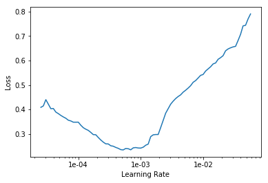

```python
clean_model.recorder.plot()
```

```python
clean_model.fit_one_cycle(1, max_lr=slice(1e-4,5e-4))
```

| epoch | train_loss | valid_loss | error_rate | time |
| --- | --- | --- | --- | --- |
| 0 | 0.523586 | 0.658246 | 0.213333 | 00:04 |

```python
clean_model.save('model-2')
```

```python
clean_model.fit_one_cycle(2, max_lr=slice(1e-4,5e-4))
```

| epoch | train_loss | valid_loss | error_rate | time |
| --- | --- | --- | --- | --- |
| 0 | 0.409237 | 0.779474 | 0.200000 | 00:04 |
| 1 | 0.373385 | 0.774910 | 0.213333 | 00:04 |

*So it appears our best error_rate is 0.2, so 1/5 will be classified wrong while randomly 2.5/5 would be classified wrong. This isn't a great result, which makes sense given that the data is quite noisy and celebrities are regular people, so apart from the fancier photos and make up, they shouldn't differ too much from everyone else.*"

### Let's put it into use

We are going to check if it can predict whether one of my favorite artists, Maggie Rogers, is classified as a celebrity or not. To be honest, I'm not even sure. She seems so down to Earth.

```python
clean_model.export()
```

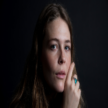

```python
img = open_image(path/'maggie.jpg')
img = img.resize(224)
img
```

```python
learn = load_learner(path)
```

```python
pred_class,pred_idx,outputs = learn.predict(img)
outputs
```

```
tensor([0.0013, 0.9987])
```

This means it predicts her as belonging to the 2nd class, which is non-celebrities. Hmmm.  
Shame it's wrong, or maybe I'll end this by saying: **She's one of us!**